# R Notebook

#MVP

#Load the diamonds.csv data set and undertake an initial exploration of the data. You will find a description of the meanings of the variables on the relevant Kaggle page

```r
 library(tidyverse)
```

```r
diamonds <- read_csv("data/diamonds.csv")
```

```
* `` -> ...1
```

#We expect the carat of the diamonds to be strong correlated with the physical dimensions x, y and z. Use ggpairs() to investigate correlations between these four variables.

```r
library(GGally)
```

[output not shown]

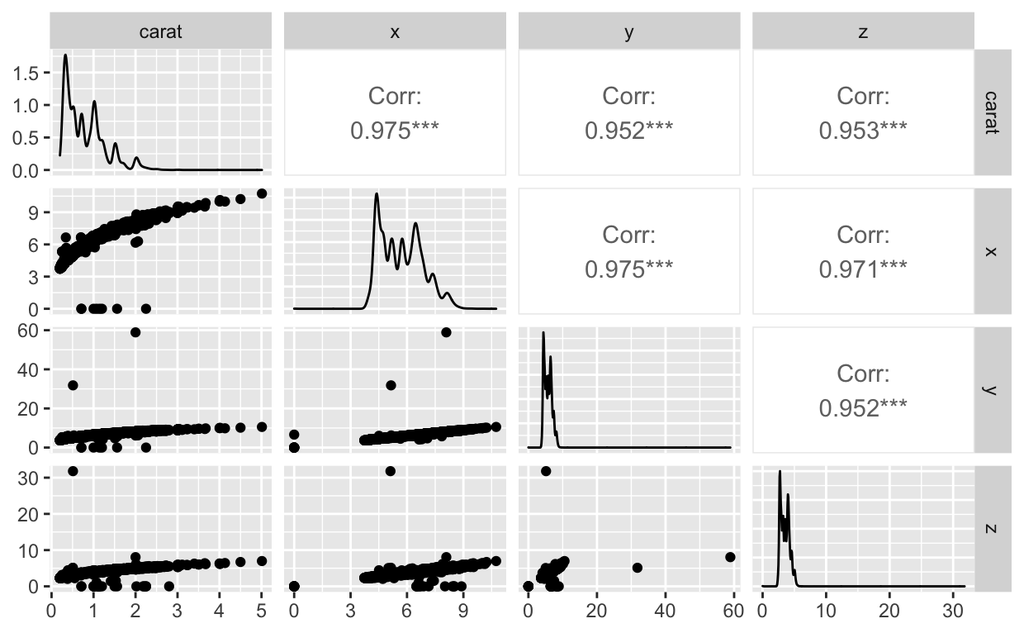

```r
ggpairs(diamonds, c("carat","x" ,"y", "z") )
```

#So, we do find significant correlations. Let’s drop columns x, y and z from the dataset, in preparation to use only carat going forward.

```r
diamonds2 <-diamonds %>%
  select(-c("x","y","z"))
diamonds2
```

| ...1 | carat | cut | color | clarity | depth | table | price |
| --- | --- | --- | --- | --- | --- | --- | --- |
| 1 | 0.23 | Ideal | E | SI2 | 61.5 | 55.0 | 326 |
| 2 | 0.21 | Premium | E | SI1 | 59.8 | 61.0 | 326 |
| 3 | 0.23 | Good | E | VS1 | 56.9 | 65.0 | 327 |
| 4 | 0.29 | Premium | I | VS2 | 62.4 | 58.0 | 334 |
| 5 | 0.31 | Good | J | SI2 | 63.3 | 58.0 | 335 |
| 6 | 0.24 | Very Good | J | VVS2 | 62.8 | 57.0 | 336 |
| 7 | 0.24 | Very Good | I | VVS1 | 62.3 | 57.0 | 336 |
| 8 | 0.26 | Very Good | H | SI1 | 61.9 | 55.0 | 337 |
| 9 | 0.22 | Fair | E | VS2 | 65.1 | 61.0 | 337 |
| 10 | 0.23 | Very Good | H | VS1 | 59.4 | 61.0 | 338 |

[output cut: 990 more lines]

#We are interested in developing a regression model for the price of a diamond in terms of the possible predictor variables in the dataset.

#Use ggpairs() to investigate correlations between price and the predictors (this may take a while to run, don’t worry, make coffee or something).

#Perform further ggplot visualisations of any significant correlations you find.

[output not shown]

[output cut: 24 more lines]

[output not shown]

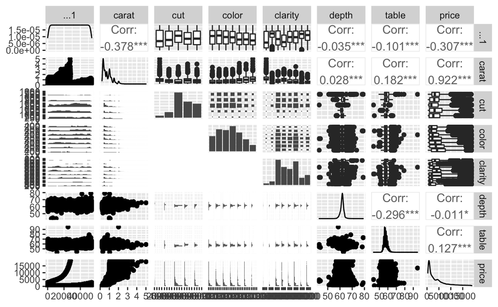

```r
ggpairs(diamonds2)
```

```r
summary(diamonds2)
```

```
      ...1           carat            cut               color
 Min.   :    1   Min.   :0.2000   Length:53940       Length:53940
 1st Qu.:13486   1st Qu.:0.4000   Class :character   Class :character
 Median :26970   Median :0.7000   Mode  :character   Mode  :character
 Mean   :26970   Mean   :0.7979
 3rd Qu.:40455   3rd Qu.:1.0400
 Max.   :53940   Max.   :5.0100
   clarity              depth           table           price
 Length:53940       Min.   :43.00   Min.   :43.00   Min.   :  326
 Class :character   1st Qu.:61.00   1st Qu.:56.00   1st Qu.:  950
 Mode  :character   Median :61.80   Median :57.00   Median : 2401
                    Mean   :61.75   Mean   :57.46   Mean   : 3933
                    3rd Qu.:62.50   3rd Qu.:59.00   3rd Qu.: 5324
                    Max.   :79.00   Max.   :95.00   Max.   :18823
```

#Perform further ggplot visualisations of any significant correlations you find.

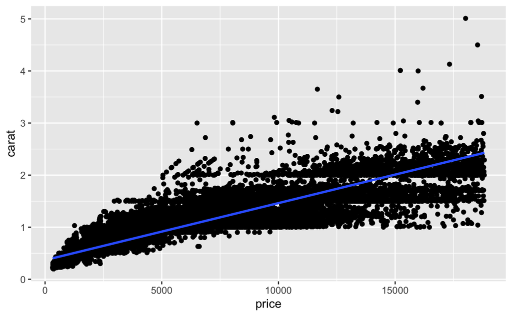

```r
diamonds2 %>%
  ggplot(aes(x = price ,y = carat ))+

  geom_point() +
  geom_smooth(method = "lm", se = FALSE)
```

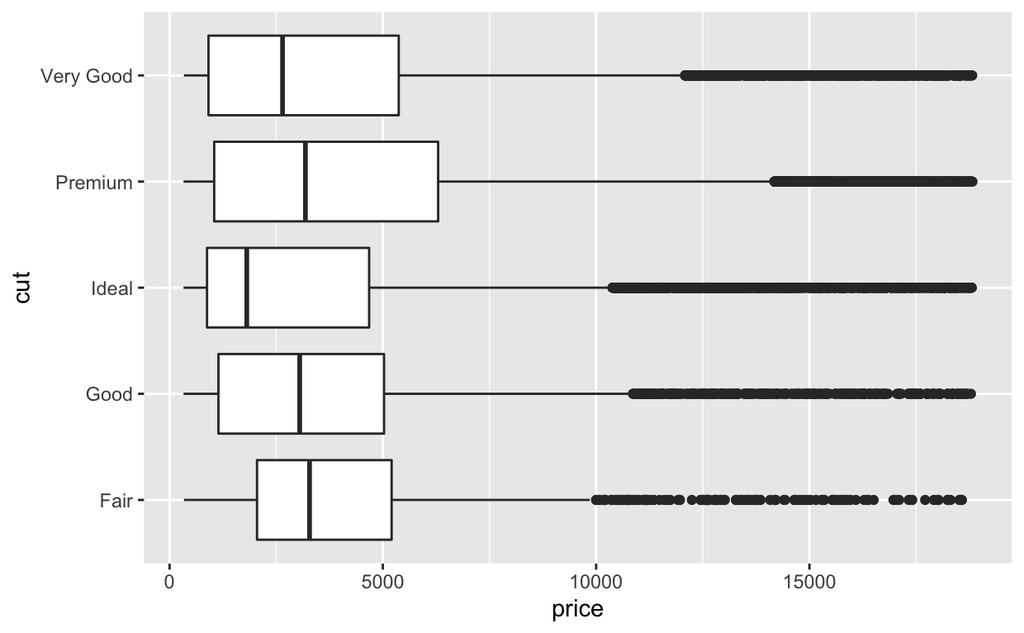

```r
diamonds2 %>%
  ggplot(aes(x =price , y = cut)) +
  geom_boxplot()
```

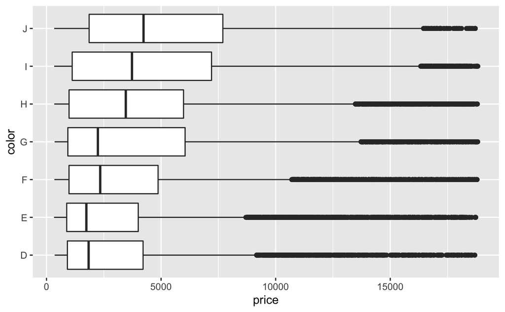

```r
diamonds2 %>%
  ggplot(aes(x =price , y = color)) +
  geom_boxplot()
```

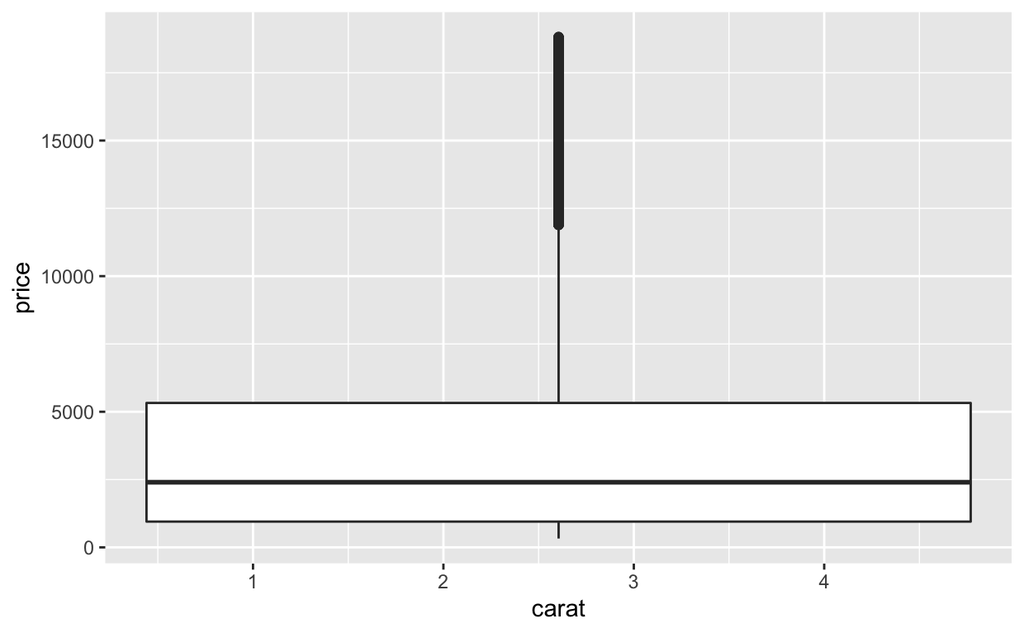

```r
diamonds2 %>%
  ggplot(aes(x = carat , y = price, group = 1)) +
  geom_boxplot()
```

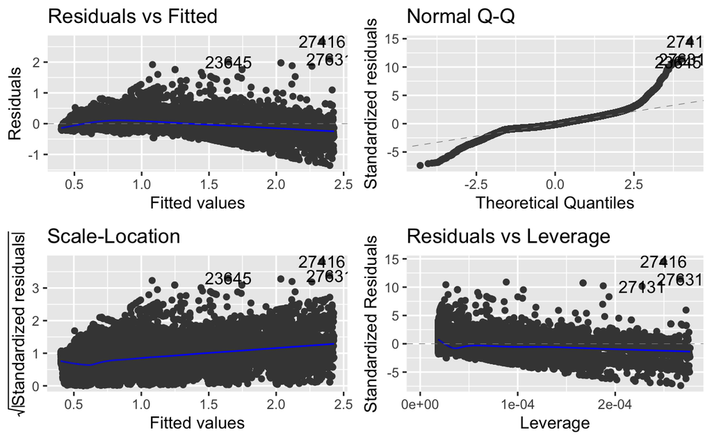

```r
library(ggfortify)

model <- lm(carat ~ price, data = diamonds2)

autoplot(model)
```

```r
summary(model)
```

```
Call:
lm(formula = carat ~ price, data = diamonds2)

Residuals:
     Min       1Q   Median       3Q      Max
-1.35765 -0.11329 -0.02442  0.10344  2.66973

Coefficients:
             Estimate Std. Error t value Pr(>|t|)
(Intercept) 3.673e-01  1.112e-03   330.2   <2e-16 ***
price       1.095e-04  1.986e-07   551.4   <2e-16 ***
---
Signif. codes:  0 ‘***’ 0.001 ‘**’ 0.01 ‘*’ 0.05 ‘.’ 0.1 ‘ ’ 1

Residual standard error: 0.184 on 53938 degrees of freedom
Multiple R-squared:  0.8493,    Adjusted R-squared:  0.8493
F-statistic: 3.041e+05 on 1 and 53938 DF,  p-value: < 2.2e-16
```

```r
library(fastDummies)
```

```r
gold_dummy <- diamonds2 %>%
  mutate(cut = ifelse(cut == "cut", 1, 0)) %>%
  mutate(clarity = ifelse(clarity == "clarity", 1, 0)) %>%
mutate(color = ifelse(color == "color", 1, 0))
head(grades_subject_dummy)
```

[output not shown]